# Credit Attrition Prediction

Matt Dunham

2022-12-13

In this document, I investigate a https://www.kaggle.com/datasets/whenamancodes/credit-card-customers-prediction?resource=download containing various customer information and their credit - from credit holder demographics (e.g. age, marital status), to credit utilization and other potentially important financial issues.

## The Problem at Hand

A manager at the bank is disturbed with more and more customers leaving their credit card services. They would really appreciate if one could predict for them who is gonna get churned so they can proactively go to the customer to provide them better services and turn customers’ decisions in the opposite direction.

Let us begin to investigate our data!

## Data Investigation

First, let’s take a look at the first few response in our data in order to ensure we clean our data properlly and get it in the right format for our prediction.

```r
credit <- read_csv("BankChurners.csv") #reading in data
head(credit) #taking a look at first few values in data
```

```
## # A tibble: 6 × 23
##   CLIEN…¹ Attri…² Custo…³ Gender Depen…⁴ Educa…⁵ Marit…⁶ Incom…⁷ Card_…⁸ Month…⁹
##     <dbl> <chr>     <dbl> <chr>    <dbl> <chr>   <chr>   <chr>   <chr>     <dbl>
## 1  7.69e8 Existi…      45 M            3 High S… Married $60K -… Blue         39
## 2  8.19e8 Existi…      49 F            5 Gradua… Single  Less t… Blue         44
## 3  7.14e8 Existi…      51 M            3 Gradua… Married $80K -… Blue         36
## 4  7.70e8 Existi…      40 F            4 High S… Unknown Less t… Blue         34
## 5  7.09e8 Existi…      40 M            3 Uneduc… Married $60K -… Blue         21
## 6  7.13e8 Existi…      44 M            2 Gradua… Married $40K -… Blue         36
## # … with 13 more variables: Total_Relationship_Count <dbl>,
## #   Months_Inactive_12_mon <dbl>, Contacts_Count_12_mon <dbl>,
## #   Credit_Limit <dbl>, Total_Revolving_Bal <dbl>, Avg_Open_To_Buy <dbl>,
## #   Total_Amt_Chng_Q4_Q1 <dbl>, Total_Trans_Amt <dbl>, Total_Trans_Ct <dbl>,
## #   Total_Ct_Chng_Q4_Q1 <dbl>, Avg_Utilization_Ratio <dbl>,
## #   Naive_Bayes_Classifier_Attrition_Flag_Card_Category_Contacts_Count_12_mon_Dependent_count_Education_Level_Months_Inactive_12_mon_1 <dbl>,
## #   Naive_Bayes_Classifier_Attrition_Flag_Card_Category_Contacts_Count_12_mon_Dependent_count_Education_Level_Months_Inactive_12_mon_2 <dbl>, …
```

We notice a few variables are numeric, and a few are categorical. Given the problem at hand is to predict attrition, we’re going to need to convert categorical variables to numeric. We can take a look at the various levels within each categorical variable and then convert said levels to numeric values.

Additionally, we’ll quickly take a look at missing values to see if we need to remove any data before starting our data cleaning process.

```r
#from the head, I see there a few categorical variables. These need to be recorded numerically for our model.
#let's take a look at the levels within each categorical variable for recoding purposes
unique(credit$Attrition_Flag)
```

```
## [1] "Existing Customer" "Attrited Customer"
```

```r
unique(credit$Education_Level)
```

```
## [1] "High School"   "Graduate"      "Uneducated"    "Unknown"
## [5] "College"       "Post-Graduate" "Doctorate"
```

```r
unique(credit$Marital_Status)
```

```
## [1] "Married"  "Single"   "Unknown"  "Divorced"
```

```r
unique(credit$Income_Category)
```

```
## [1] "$60K - $80K"    "Less than $40K" "$80K - $120K"   "$40K - $60K"
## [5] "$120K +"        "Unknown"
```

```r
unique(credit$Card_Category)
```

```
## [1] "Blue"     "Gold"     "Silver"   "Platinum"
```

```r
kable(colSums(is.na(credit)), col.names = "NA Count") #are there any NAs? No.
```

|  | NA Count |
| --- | --- |
| CLIENTNUM | 0 |
| Attrition_Flag | 0 |
| Customer_Age | 0 |
| Gender | 0 |
| Dependent_count | 0 |
| Education_Level | 0 |
| Marital_Status | 0 |
| Income_Category | 0 |
| Card_Category | 0 |
| Months_on_book | 0 |
| Total_Relationship_Count | 0 |
| Months_Inactive_12_mon | 0 |
| Contacts_Count_12_mon | 0 |
| Credit_Limit | 0 |
| Total_Revolving_Bal | 0 |
| Avg_Open_To_Buy | 0 |
| Total_Amt_Chng_Q4_Q1 | 0 |
| Total_Trans_Amt | 0 |
| Total_Trans_Ct | 0 |
| Total_Ct_Chng_Q4_Q1 | 0 |
| Avg_Utilization_Ratio | 0 |
| Naive_Bayes_Classifier_Attrition_Flag_Card_Category_Contacts_Count_12_mon_Dependent_count_Education_Level_Months_Inactive_12_mon_1 | 0 |
| Naive_Bayes_Classifier_Attrition_Flag_Card_Category_Contacts_Count_12_mon_Dependent_count_Education_Level_Months_Inactive_12_mon_2 | 0 |

## Data Cleaning

Now that we’ve identified categorical variables, their respective levels and determined there aren’t missing values present, we can recode our categorical variables. Ideally, these levels will be continuous and have a proper order, although, it appears martial status may be lacking this assumption.

```r
#time for data cleaning. Our main goal is to recode the categorical variables, but we'll also remove a few unnecessary variables.
#we can do this in one pipe.
credit_cleaned_inc <- credit %>% #pipe into new, cleaned data frame

  mutate(Attrition_Flag = ifelse(Attrition_Flag == "Existing Customer", 1, 0)) %>% #recode attrition

  mutate(Gender = ifelse(Gender == "M", 1, 0)) %>%

  mutate(Education_Level = case_when(Education_Level == "Unknown" ~ 1, #recode educaiton level
                                     Education_Level == "Uneducated" ~ 2,
                                     Education_Level == "High School" ~ 3,
                                     Education_Level == "College" ~ 4,
                                     Education_Level == "Graduate" ~ 5,
                                     Education_Level == "Post-Graduate" ~ 6,
                                     Education_Level == "Doctorate" ~ 7)) %>%

  mutate(Marital_Status = case_when(Marital_Status == "Unknown" ~ 1, #recode marital status...not as obvious of an order here...
                                    Marital_Status == "Single" ~ 2,
                                    Marital_Status == "Married" ~ 3,
                                    Marital_Status == "Divorced" ~ 4)) %>%

  mutate(Income_Category = case_when(Income_Category == "Unknown" ~ 1, #recode income
                                     Income_Category == "Less than $40K" ~ 2,
                                     Income_Category == "$40K - $60K" ~ 3,
                                     Income_Category == "$60K - $80K" ~ 4,
                                     Income_Category == "$80K - $120K" ~ 5,
                                     Income_Category == "$120K +" ~ 6)) %>%

  mutate(Card_Category = case_when(Card_Category == "Blue" ~ 1, #recode card type
                                    Card_Category == "Gold" ~ 2,
                                    Card_Category == "Silver" ~ 3,
                                    Card_Category == "Platinum" ~ 4)) %>%

  #these columns are arbitrary, so we'll remove them
  dplyr::select(-Naive_Bayes_Classifier_Attrition_Flag_Card_Category_Contacts_Count_12_mon_Dependent_count_Education_Level_Months_Inactive_12_mon_1,
                -Naive_Bayes_Classifier_Attrition_Flag_Card_Category_Contacts_Count_12_mon_Dependent_count_Education_Level_Months_Inactive_12_mon_2)
```

Additionally, we remove two columns that won’t serve us any purpose in this analysis.

## Determining Normality

Now that our data is clean, we can look into the normality of our numeric variables. This normality assumption is important for our future logistic regression and prediction, so we can determine which variables are normal and which are not.

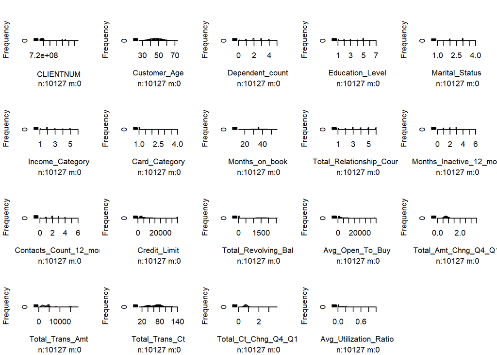

```r
#We need to investigate the skewness of our variables to run out logistic regression. We can generate a histogram to visualy check, and further calculate skewness.
hist.data.frame(credit_cleaned_inc) #hist of variables
```

```r
abs(skewness(credit_cleaned_inc)) > 1 #checking if skewness is too much. If true, it's too large
```

```
##                CLIENTNUM           Attrition_Flag             Customer_Age
##                    FALSE                     TRUE                    FALSE
##                   Gender          Dependent_count          Education_Level
##                    FALSE                    FALSE                    FALSE
##           Marital_Status          Income_Category            Card_Category
##                    FALSE                    FALSE                     TRUE
##           Months_on_book Total_Relationship_Count   Months_Inactive_12_mon
##                    FALSE                    FALSE                    FALSE
##    Contacts_Count_12_mon             Credit_Limit      Total_Revolving_Bal
##                    FALSE                     TRUE                    FALSE
##          Avg_Open_To_Buy     Total_Amt_Chng_Q4_Q1          Total_Trans_Amt
##                     TRUE                     TRUE                     TRUE
##           Total_Trans_Ct      Total_Ct_Chng_Q4_Q1    Avg_Utilization_Ratio
##                    FALSE                     TRUE                    FALSE
```

We can see that a few variables are lacking normality and have too high or low skew. Given we aren’t aiming to interpret any aspect of our predictors, we’ll procede with a log-transformation on these variables in hopes we can deal with the skewness.

```r
#we can then transform variables to help with the skewness. Log transforming variables won't impact our inference given we're predicting.
abs(skewness(log(credit_cleaned_inc$Card_Category))) #can't remove skewness...we'll drop this later
```

```
## [1] 3.55397
```

```r
abs(skewness(log(credit_cleaned_inc$Credit_Limit)))
```

```
## [1] 0.457013
```

```r
abs(skewness(log(credit_cleaned_inc$Avg_Open_To_Buy)))
```

```
## [1] 0.1001167
```

```r
abs(skewness(log(credit_cleaned_inc$Total_Amt_Chng_Q4_Q1  + .1)))
```

```
## [1] 0.5019251
```

```r
abs(skewness(log(credit_cleaned_inc$Total_Trans_Amt)))
```

```
## [1] 0.2621716
```

```r
abs(skewness(log(credit_cleaned_inc$Total_Ct_Chng_Q4_Q1 + .1)))
```

```
## [1] 0.7522563
```

```r
#skewness looks good now! let's reassign variables
```

After log-transforming our skewed variables, we seem to get rid of a lot of the skewness issues. It appeared Card_Category remains highly skewed due to the sheer proportion of individuals having a blue card, so we’ll drop this variable in our final, cleaned dataset.

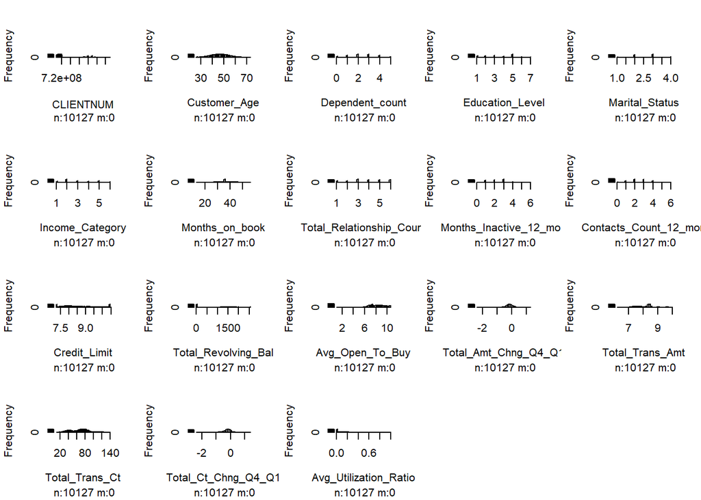

```r
#reassigning log-transformed variables to new dataset
credit_cleaned <- credit_cleaned_inc %>%
  mutate(Credit_Limit = log(Credit_Limit)) %>%
  mutate(Avg_Open_To_Buy = log(Avg_Open_To_Buy)) %>%
  mutate(Total_Amt_Chng_Q4_Q1 = log(Total_Amt_Chng_Q4_Q1  + .1)) %>%
  mutate(Total_Trans_Amt = log(Total_Trans_Amt)) %>%
  mutate(Total_Ct_Chng_Q4_Q1 = log(Total_Ct_Chng_Q4_Q1 + .1)) %>%
  dplyr::select(-Card_Category) #removing pesky skewed variable

#looking good now!
hist.data.frame(credit_cleaned)
```

```r
abs(skewness(credit_cleaned)) > 1
```

```
##                CLIENTNUM           Attrition_Flag             Customer_Age
##                    FALSE                     TRUE                    FALSE
##                   Gender          Dependent_count          Education_Level
##                    FALSE                    FALSE                    FALSE
##           Marital_Status          Income_Category           Months_on_book
##                    FALSE                    FALSE                    FALSE
## Total_Relationship_Count   Months_Inactive_12_mon    Contacts_Count_12_mon
##                    FALSE                    FALSE                    FALSE
##             Credit_Limit      Total_Revolving_Bal          Avg_Open_To_Buy
##                    FALSE                    FALSE                    FALSE
##     Total_Amt_Chng_Q4_Q1          Total_Trans_Amt           Total_Trans_Ct
##                    FALSE                    FALSE                    FALSE
##      Total_Ct_Chng_Q4_Q1    Avg_Utilization_Ratio
##                    FALSE                    FALSE
```

Skewness now looks good, and we can proceed to the prediction stage!